# --- SECCIÓN: 01 DESCARGAR PVWATTS ---

## Código 1 — Descarga y preparación de datos PVWatts

En esta primera etapa se descarga una simulación horaria desde PVWatts para Santiago, usando las coordenadas efectivas de la fuente climática reportada por PVWatts.

Si PVWatts no encuentra datos en `dataset=nsrdb`, el código intenta con `dataset=intl`. Para mantener consistencia espacial, la solicitud y la reconstrucción de `ghi` usan las mismas coordenadas efectivas de Santiago.

PVWatts entrega directamente:

- `dni`: irradiancia directa normal.
- `dhi`: irradiancia difusa horizontal.
- `poa`: irradiancia sobre el plano del panel.
- `dc`: potencia DC simulada.
- `ac`: potencia AC simulada.
- `temperature`: temperatura ambiente.
- `tcell_pvwatts`: temperatura de celda estimada por PVWatts.
- `wind_speed`: velocidad del viento.
- `albedo`: reflectancia del suelo.

Luego, el código calcula:

- `ghi = dni * cos(zenith) + dhi`, usando la geometría solar local de Santiago.
- `fd = dhi / ghi` como fracción difusa.
- `regimen_fd`, clasificando cada hora en `baja_fd`, `mixto` o `alta_fd`.

Finalmente, guarda una base limpia en formato CSV para usarla en los siguientes pasos del análisis.

```python
# ============================================================
# CODIGO 1: DESCARGA Y PREPARACION DE DATOS PVWATTS
# ============================================================
# Este notebook crea la primera base del proyecto.
# Descarga una simulacion horaria desde PVWatts, reconstruye GHI,
# calcula la fraccion difusa y deja un CSV listo para los codigos siguientes.

# Librerias estandar: se usan para archivos, rutas, fechas y metadata.
import json
import os
from pathlib import Path
from datetime import timezone, timedelta

# Librerias cientificas:
# numpy y pandas manejan calculos numericos/tablas;
# requests consulta la API;
# pvlib calcula la posicion solar.
import numpy as np # Sirve para calculos numericos y algebra lineal
import pandas as pd # Sirve para manejar tablas y series temporales
import requests # Sirve para hacer consultas HTTP a la API
import pvlib # Sirve para calcular la geometria solar y la posicion del sol


# Configuracion de la API.
# Esta es la clave  solicitada para consultar PVWatts.
API_KEY = "rpKQ7B8DbjeA5ZIzu0254FiWbWf1USkJmFJpED2y"
PVWATTS_URL = "https://developer.nlr.gov/api/pvwatts/v8.json" #Esta url la usamos para hacer la consulta a PVWatts. No se debe cambiar.

# Ubicacion efectiva del estudio.
# Estas coordenadas se usan tanto para consultar PVWatts como para la geometria solar.
# Ubicacion: Santiago, Chile
LAT = -33.38000106811523
LON = -70.77999877929688

# Parametros del sistema FV simulado para la descarga de PVWatts. Estos parametros los usara el codigo 2 para simular la potencia de un sistema FV real.
# Con sistema fotovoltaico se refiere a un arreglo de paneles solares que convierte la energia solar en electricidad. La potencia de un sistema FV depende de la cantidad de paneles, su eficiencia y su orientacion.
# Deben mantenerse consistentes con el informe y con el modelo NOCT del codigo 2.
# Parametros estandar del sistema fotovoltaico
SYSTEM_CAPACITY = 1.0   # kW DC esto es un valor tipico para techos residenciales; no es la potencia de un sistema real.
AZIMUTH = 0             # norte, recomendado para hemisferio sur porque el sol esta al norte. Su unidad es grados. 0=norte, 90=este, 180=sur, 270=oeste.
TILT = 20               # esto es un valor tipico para techos inclinados en Santiago, Chile. Su unidad es grados. 0=horizontal, 90=vertical.
ARRAY_TYPE = 1          # fixed roof mounted es el tipo de arreglo mas comun y barato
MODULE_TYPE = 0         # standard es el tipo de modulo mas comun y barato
LOSSES = 14             # % es una estimacion de perdidas del sistema

# PVWatts entrega un año meteorologico tipico, no una serie historica real.
# BASE_YEAR solo permite construir una columna de fechas ordenadas.
BASE_YEAR = 2021        # solo para construir fechas; no es año historico real.

# Umbral para calcular fd = DHI/GHI.
# Con GHI muy bajo, el cociente se vuelve numericamente inestable y poco informativo. El cociente es una medida de la fraccion difusa, que es la variable diagnostica central del proyecto.
GHI_MIN_FOR_FD = 10

# Coordenadas efectivas usadas para la solicitud y la geometria solar local de Santiago.
SOLAR_GEOMETRY_LAT = LAT
SOLAR_GEOMETRY_LON = LON

# Archivos generados por este notebook.
# El CSV contiene los datos horarios; el JSON documenta como se obtuvo la base.
OUT_DIR = Path("data") # Esta linea hace que la carpeta data se cree si no existe. Se recomienda mantenerla asi para que el proyecto sea reproducible.
OUT_FILE = OUT_DIR / "01_pvwatts_santiago.csv" # Esta linea hace que el csv se guarde con ese nombre dentro de la carpeta data
OUT_META = OUT_DIR / "01_pvwatts_santiago_metadata.json"


# DESCARGA PVWATTS
def request_pvwatts(dataset: str) -> dict:  # str es el tipo de dato que se espera para dataset; dict es el tipo de dato que devuelve la funcion.
    # Esta funcion hace una consulta individual a PVWatts para el dataset pedido.
    # Devuelve el JSON completo si la respuesta es valida.
    url = PVWATTS_URL

    # Parametros enviados a PVWatts.
    # timeframe='hourly' es clave porque el diagnostico se realiza hora a hora.
    params = {
        "api_key": API_KEY,
        "lat": LAT,
        "lon": LON,
        "system_capacity": SYSTEM_CAPACITY,
        "azimuth": AZIMUTH,
        "tilt": TILT,
        "array_type": ARRAY_TYPE,
        "module_type": MODULE_TYPE,
        "losses": LOSSES,
        "timeframe": "hourly",
        "dataset": dataset, # no se especifica de donde viene la base climatica; PVWatts decide automaticamente. Se prueba primero NSRDB y luego el dataset internacional.
    }

    # Se usa timeout para que el notebook no quede colgado si la API demora demasiado.
    response = requests.get(url, params=params, timeout=90)

    print(f"\nIntento con dataset='{dataset}'") # Esto es para diagnostico; indica que se esta probando un dataset en particular.
    print("Status code:", response.status_code) # Esto es para diagnostico; indica el codigo de estado HTTP de la respuesta.

    # La respuesta deberia venir en formato JSON.
    # Si no viene asi, se imprime parte del texto para diagnosticar el problema.
    try:
        data = response.json()
    except ValueError:
        print("Respuesta no JSON:")
        print(response.text[:1000])
        response.raise_for_status()
        raise

    if response.status_code != 200:
        print("Respuesta de PVWatts:")
        print(json.dumps(data, indent=2, ensure_ascii=False)[:2000])
        response.raise_for_status()

    # PVWatts puede responder con codigo HTTP valido pero reportar errores internos.
    # Si hay errores, no se continua porque la base no seria confiable.
    if data.get("errors"):
        print("Errores reportados por PVWatts:")
        print(data["errors"])
        raise RuntimeError(f"Errores desde PVWatts con dataset={dataset}: {data['errors']}")

    return data


def download_pvwatts():
    # Se prueba primero NSRDB y luego el dataset internacional.
    # El dataset que finalmente funcione queda registrado en _dataset_used.
    """
    Primero intenta con NSRDB.
    Si Santiago no está disponible ahí para PVWatts, intenta con dataset internacional.
    """
    datasets_to_try = ["nsrdb", "intl"]
```

```python
    last_error = None

    for dataset in datasets_to_try:
        try:
            data = request_pvwatts(dataset)
            data["_dataset_used"] = dataset
            return data

        except Exception as e:
            last_error = e
            safe_error = str(e).replace(API_KEY, "***")
            print(f"Fallo con dataset='{dataset}': {safe_error}")

    raise RuntimeError(
        "No se pudo descargar PVWatts para esta ubicacion con los datasets probados. "
        f"Ultimo error: {last_error}"
    )


# ARMAR DATAFRAME
def build_dataframe(data):
    # Convierte la respuesta de PVWatts en una tabla ordenada.
    # Aqui se calculan GHI, fd y regimen_fd, variables centrales para la tesis.
    outputs = data["outputs"] # Esta linea extrae la parte de la respuesta de PVWatts que contiene los resultados horarios de irradiancia, potencia y meteorologia.
    station_info = data["station_info"] # Aqui se extrae la informacion de la estacion meteorologica que provee los datos climáticos a PVWatts.

    # PVWatts informa el huso horario de la fuente climatica.
    # Se usa para construir una serie horaria local coherente.
    tz_offset = float(station_info["tz"]) # Esta linea extrae el offset horario de la estacion meteorologica. Por ejemplo, para Santiago, Chile, el offset es -4 o -3 dependiendo de si es horario de verano o no.
    tzinfo = timezone(timedelta(hours=tz_offset)) # Aqui se construye un objeto de zona horaria a partir del offset horario. Este objeto se usa para crear la serie horaria local.

    n = len(outputs["dc"]) # Esta linea obtiene la cantidad de horas de datos que PVWatts ha devuelto. Para un año tipico, n deberia ser 8760 horas.

    # Se construye una fecha por cada hora de la simulacion.
    # Para un año tipico se esperan 8760 horas.
    # Todo este bloque construye una serie de fechas y horas locales para cada hora de la simulacion de PVWatts.
    datetime_local = pd.date_range(
        start=f"{BASE_YEAR}-01-01 00:00:00",
        periods=n,
        freq="h",
        tz=tzinfo,
    )

    # Tabla principal con irradiancia, potencia, temperatura y viento.
    # Estos nombres se reutilizan en todos los codigos posteriores.

    # Todo el bloque siguiente construye un DataFrame de pandas con todas las variables de interes, incluyendo irradiancia, potencia, temperatura y viento. Se incluyen tambien columnas de fecha y hora para facilitar el analisis temporal.
    # Aqui se crea una zona horaria local para cada fecha y hora de la simulacion, y se extraen las componentes de fecha y hora (año, mes, día, hora) para cada registro. Esto permite analizar los datos por periodos de tiempo especificos.
    df = pd.DataFrame({
        "datetime_local": datetime_local.tz_localize(None),
        "year": datetime_local.year,
        "month": datetime_local.month,
        "day": datetime_local.day,
        "hour": datetime_local.hour,

        # Variables solares PVWatts
        "dni": outputs["dn"],
        "dhi": outputs["df"],
        "poa": outputs["poa"],

        # Potencia simulada
        "dc": outputs["dc"],
        "ac": outputs["ac"],

        # Variables meteorologicas/simuladas
        "temperature": outputs["tamb"],
        "tcell_pvwatts": outputs["tcell"],
        "wind_speed": outputs["wspd"],
        "albedo": outputs["alb"],
    })

    # Calcular GHI aproximado desde DNI, DHI y posicion solar.
    # Se usa la geometria solar de las mismas coordenadas efectivas de Santiago.
    # GHI se reconstruye como DNI*cos(zenit) + DHI.
    # Para eso primero se calcula la posicion solar con pvlib.
    solar_position = pvlib.solarposition.get_solarposition(
        time=datetime_local,
        latitude=SOLAR_GEOMETRY_LAT,
        longitude=SOLAR_GEOMETRY_LON,
    )

    # Durante la noche cos(zenit) puede ser negativo.
    # Fisicamente la componente directa horizontal no debe ser negativa.
    cos_zenith = np.cos(np.deg2rad(solar_position["zenith"].to_numpy())) # Aqui se calcula el coseno del angulo cenital solar a partir de la posicion solar obtenida con pvlib. Se convierte de grados a radianes para poder usar la funcion coseno de numpy.
    cos_zenith = np.where(cos_zenith > 0, cos_zenith, 0) # Y aqui se asegura que el coseno del angulo cenital no sea negativo, ya que durante la noche el sol esta por debajo del horizonte y la componente directa horizontal de irradiancia no puede ser negativa.

    # Reconstruccion de la irradiancia global horizontal.
    df["ghi"] = df["dni"] * cos_zenith + df["dhi"] # Aqui se reconstruye la irradiancia global horizontal (GHI) a partir de la irradiancia directa normal (DNI), el coseno del angulo cenital solar y la irradiancia difusa horizontal (DHI). La formula es GHI = DNI * cos(zenith) + DHI.
    df["ghi"] = df["ghi"].clip(lower=0) # Y aqui se asegura que la irradiancia global horizontal (GHI) no sea negativa, ya que fisicamente no puede serlo. Se usa la funcion clip de pandas para limitar los valores a un minimo de 0.

    # Fraccion difusa: fd = DHI / GHI
    # fd mide que parte de la irradiancia global es difusa.
    # Esta es la variable diagnostica principal del proyecto.
    df["fd"] = np.nan # Inicializa la columna fd con NaN. Esto es importante para evitar errores de division por cero o valores no definidos cuando GHI es muy bajo.
    mask = df["ghi"] > GHI_MIN_FOR_FD # Se crea una mascara booleana para seleccionar solo las filas donde GHI es mayor que un umbral minimo. Esto evita que la division DHI/GHI sea numericamente inestable cuando GHI es muy bajo.
    # Calcula fd solo donde ghi > GHI_MIN_FOR_FD
    df.loc[mask, "fd"] = df.loc[mask, "dhi"] / df.loc[mask, "ghi"] # Y aqui se calcula la fraccion difusa (fd) solo para las filas donde GHI es suficientemente grande. La formula es fd = DHI / GHI.

    # Por definicion fisica fd debe estar entre 0 y 1.
    df.loc[(df["fd"] < 0) | (df["fd"] > 1), "fd"] = np.nan # Y aqui se asegura que los valores de fd esten entre 0 y 1. Si fd es menor que 0 o mayor que 1, se reemplaza por NaN, ya que fisicamente no tiene sentido.
```

```python
    # Clasificacion por regimen radiativo:
    # baja_fd: domina directa; mixto: intermedio; alta_fd: domina difusa.
    df["regimen_fd"] = pd.cut(
        df["fd"],
        bins=[-np.inf, 0.3, 0.7, np.inf],
        labels=["baja_fd", "mixto", "alta_fd"],
        right=False,
    )

    # Orden final de columnas para que la base sea facil de leer y estable.
    df = df[
        [
            "datetime_local",
            "year",
            "month",
            "day",
            "hour",
            "ghi",
            "dhi",
            "dni",
            "fd",
            "regimen_fd",
            "poa",
            "dc",
            "ac",
            "temperature",
            "tcell_pvwatts",
            "wind_speed",
            "albedo",
        ]
    ]

    return df


def save_metadata(data):
    # Guarda informacion metodologica para reproducir la descarga y justificar la fuente.
    metadata = {
        "note": "PVWatts entrega una simulacion horaria tipo TMY, no datos historicos reales.",
        "location_requested": {
            "lat": LAT,
            "lon": LON,
            "city": "Santiago, Chile",
        },
        "system_parameters": {
            "system_capacity_kw": SYSTEM_CAPACITY,
            "azimuth": AZIMUTH,
            "tilt": TILT,
            "array_type": ARRAY_TYPE,
            "module_type": MODULE_TYPE,
            "losses_percent": LOSSES,
        },
        "dataset_used": data.get("_dataset_used"),
        "solar_geometry_used": {
            "lat": SOLAR_GEOMETRY_LAT,
            "lon": SOLAR_GEOMETRY_LON,
            "note": "GHI reconstruido con la geometria solar de las coordenadas efectivas de Santiago usadas en la consulta.",
        },
        "station_info": data.get("station_info"),
        "warnings": data.get("warnings"),
        "version": data.get("version"),
    }

    with open(OUT_META, "w", encoding="utf-8") as f:
        json.dump(metadata, f, indent=4, ensure_ascii=False)



# EJECUCION
def main():
    # Ejecuta todo el flujo: descarga, construccion de base, guardado y diagnostico.
    OUT_DIR.mkdir(parents=True, exist_ok=True)

    print("Descargando PVWatts para Santiago...")
    data = download_pvwatts() #

    print("\nDataset usado:")
    print(data.get("_dataset_used"))

    print("\nStation info:")
    print(json.dumps(data.get("station_info"), indent=2, ensure_ascii=False))

    print("\nGeometria solar usada para reconstruir GHI:")
    print({"lat": SOLAR_GEOMETRY_LAT, "lon": SOLAR_GEOMETRY_LON})

    print("\nArmando base...")
    df = build_dataframe(data)

    print("Guardando archivo...")
    # Este CSV es la entrada directa del codigo 2.
    df.to_csv(OUT_FILE, index=False)
    save_metadata(data)

    print("\nArchivo guardado:")
    print(OUT_FILE)

    print("\nMetadata guardada:")
    print(OUT_META)

    print("\nDimensiones:")
    print(df.shape)

    print("\nColumnas:")
    print(df.columns.tolist())

    print("\nConteo por regimen_fd:")
    print(df["regimen_fd"].value_counts(dropna=False))

    # Resumen rapido para verificar rangos fisicos y detectar valores raros.
    print("\nResumen:")
    print(
        df[
            [
                "ghi",
                "dhi",
                "dni",
                "fd",
                "poa",
                "dc",
                "ac",
                "temperature",
                "wind_speed",
            ]
        ].describe()
    )

    print("\nPrimeras filas:")
    print(df.head(24))


if __name__ == "__main__":
    main()
```

```
Descargando PVWatts para Santiago...
```

[output not shown]

```
Intento con dataset='intl'
Status code: 200

Dataset usado:
intl

Station info:
{
  "lat": -33.38000106811523,
  "lon": -70.77999877929688,
  "elev": 476.0,
  "tz": -4.0,
  "location": "855740",
  "city": "Santiago",
  "state": "CHL",
  "solar_resource_file": "855740.tm3",
  "distance": 0,
  "weather_data_source": "PVWatts International"
}

Geometria solar usada para reconstruir GHI:
{'lat': -33.38000106811523, 'lon': -70.77999877929688}

Armando base...
```

```
Guardando archivo...
```

```
Archivo guardado:
data\01_pvwatts_santiago.csv

Metadata guardada:
data\01_pvwatts_santiago_metadata.json

Dimensiones:
(8760, 17)

Columnas:
['datetime_local', 'year', 'month', 'day', 'hour', 'ghi', 'dhi', 'dni', 'fd', 'regimen_fd', 'poa', 'dc', 'ac', 'temperature', 'tcell_pvwatts', 'wind_speed', 'albedo']

Conteo por regimen_fd:
regimen_fd
NaN        4545
alta_fd    1740
baja_fd    1349
mixto      1126
Name: count, dtype: int64

Resumen:
               ghi          dhi          dni           fd          poa  \
count  8760.000000  8760.000000  8760.000000  4215.000000  8760.000000
mean    203.731461    74.140982   186.311187     0.579686   220.566199
std     305.563741    98.173962   308.031719     0.331185   330.481056
min       0.000000     0.000000     0.000000     0.091565     0.000000
25%       0.000000     0.000000     0.000000     0.237359     0.000000
50%       5.000000     5.000000     0.000000     0.562035     4.720000
75%     338.586160   145.000000   297.000000     0.962752   361.646000
max    1088.674890   593.000000   996.000000     1.000000  1105.373000

                dc           ac  temperature   wind_speed
count  8760.000000  8760.000000  8760.000000  8760.000000
mean    176.102894   167.866342    14.433813     2.106518
std     259.724000   249.191518     7.177769     1.815062
min       0.000000     0.000000    -6.000000     0.000000
25%       0.000000     0.000000     9.000000     1.000000
50%       2.529500     0.000000    13.550000     1.500000
75%     301.758750   287.102750    19.000000     3.100000
max     868.195000   833.333000    33.200000    24.200000
```

[output cut: 64 more lines]

```
9          48.979         1.0    0.15
10         47.098         3.1    0.15
11         50.984         3.1    0.15
12         67.841         1.0    0.15
13         51.335         4.1    0.15
14         46.634         5.1    0.15
15         41.479         6.2    0.15
16         37.018         6.2    0.15
17         30.721         7.2    0.15
18         26.261         5.1    0.15
19         23.073         1.0    0.15
20         19.000         3.6    0.15
21         17.000         3.6    0.15
22         16.000         4.1    0.15
23         15.000         2.1    0.15
```

# --- SECCIÓN: 02 NOCT VS PVWATTS ---

## Código 2 — Modelo NOCT y residuo

Este código toma la base generada por PVWatts para Santiago y calcula un modelo físico NOCT propio.

Se usa `dc` de PVWatts como potencia de referencia simulada (`p_ref_dc`) y se calcula `p_noct` usando `poa`, temperatura ambiente y parámetros estándar del panel.

Luego se calcula el residuo:

`epsilon = p_ref_dc - p_noct`

También se generan errores absolutos, errores relativos y una columna `is_valid_model` para filtrar las horas útiles en el diagnóstico y en el entrenamiento posterior.

```python
def plot_eda(df: pd.DataFrame) -> None:
    """Genera graficos de EDA (histogramas) para variables clave y los guarda en disco."""
    import matplotlib.pyplot as plt
    import seaborn as sns
    from pathlib import Path

    out_dir = Path("outputs/02_eda_santiago")
    out_dir.mkdir(parents=True, exist_ok=True)

    valid = df[df["is_valid_model"]].copy()

    variables = ["ghi", "poa", "temperature", "wind_speed", "p_ref_dc"]
    nombres = {
        "ghi": "GHI [W/m²]",
        "poa": "POA [W/m²]",
        "temperature": "Temperatura Ambiente [°C]",
        "wind_speed": "Velocidad del Viento [m/s]",
        "p_ref_dc": "Potencia de Referencia [W]"
    }

    plt.figure(figsize=(15, 10))
    for i, var in enumerate(variables, 1):
        plt.subplot(2, 3, i)
        sns.histplot(valid[var], bins=30, kde=True, color="#3498db")
        plt.title(f"Distribución de {nombres[var]}")
        plt.xlabel(nombres[var])
        plt.ylabel("Frecuencia (Horas)")

    plt.tight_layout()
    plt.savefig(out_dir / "eda_histogramas.png", dpi=300)
    plt.close()

    print("\n--- Análisis Exploratorio de Datos (EDA) ---")
    print("Estadísticas Descriptivas (Horas válidas):")
    print(valid[variables].describe().round(2))
    print(f"\nGráfico EDA guardado en: {out_dir / 'eda_histogramas.png'}")
```

```python
# ============================================================
# CODIGO 2: MODELO NOCT Y RESIDUO RESPECTO A PVWATTS
# ============================================================
# Este notebook calcula un modelo fisico propio (NOCT) y lo compara
# contra la potencia DC simulada por PVWatts. El resultado principal
# es el residuo epsilon, que luego se diagnostica y se aprende con XGBoost.
from pathlib import Path
import json

import numpy as np
import pandas as pd
import matplotlib.pyplot as plt
import seaborn as sns

# Archivos de entrada y salida.
# La entrada viene del codigo 1; la salida alimenta los codigos 3 y 4.
INPUT_FILE = Path("data/01_pvwatts_santiago.csv")
OUT_FILE = Path("data/02_noct_vs_pvwatts_santiago.csv")
OUT_META = Path("data/02_noct_vs_pvwatts_santiago_metadata.json")

# Parametros fisicos del sistema.
# PDC0_W corresponde a 1 kW nominal y SYSTEM_LOSSES replica las perdidas de PVWatts.
# Parámetros del sistema fotovoltaico
PDC0_W = 1000.0          # sistema FV de 1 kW DC
SYSTEM_LOSSES = 0.14     # debe coincidir con LOSSES = 14 del Código 1

# Parametros del modelo NOCT.
# G_REF y T_REF son condiciones de referencia; GAMMA corrige por temperatura.
# Parámetros del modelo NOCT
G_REF = 1000.0           # W/m2
T_REF = 25.0             # °C
NOCT = 45.0              # °C
GAMMA = -0.004           # 1/°C

# Filtros para dejar fuera horas nocturnas o casos con irradiancia/potencia casi nula.
# Filtros para diagnóstico/modelado
GHI_MIN = 10.0
POA_MIN = 10.0
# El error relativo solo se calcula si la potencia de referencia supera este umbral.
# Asi se evita dividir por valores muy pequenos.
P_REF_MIN_RELATIVE_ERROR = 50.0



# FUNCIONES
def validate_input(df: pd.DataFrame) -> None:
    # Verifica que la base tenga todas las columnas que el modelo necesita.
    required_columns = [
        "datetime_local",
        "year",
        "month",
        "day",
        "hour",
        "ghi",
        "dhi",
        "dni",
        "fd",
        "regimen_fd",
        "poa",
        "dc",
        "ac",
        "temperature",
        "tcell_pvwatts",
        "wind_speed",
        "albedo",
    ]

    missing = [col for col in required_columns if col not in df.columns]

    if missing:
        raise ValueError(f"Faltan columnas requeridas en la base PVWatts: {missing}")


def prepare_data(df: pd.DataFrame) -> pd.DataFrame:
    # Convierte columnas numericas y fija el orden de los regimenes de fd.
    numeric_columns = [
        "year",
        "month",
        "day",
        "hour",
        "ghi",
        "dhi",
        "dni",
        "fd",
        "poa",
        "dc",
        "ac",
        "temperature",
        "tcell_pvwatts",
        "wind_speed",
        "albedo",
    ]

    # errors='coerce' transforma valores invalidos en NaN sin romper el flujo.
    for col in numeric_columns:
        df[col] = pd.to_numeric(df[col], errors="coerce")

    # Orden fijo para gráficos y tablas posteriores
    df["regimen_fd"] = pd.Categorical(
        df["regimen_fd"],
        categories=["baja_fd", "mixto", "alta_fd"],
        ordered=True,
    )

    return df


# ------------------------------------------------------------
# Modelo fisico NOCT
# ------------------------------------------------------------
def calculate_noct(df: pd.DataFrame) -> pd.DataFrame:
    """
    Calcula el modelo NOCT base.

    Se calculan dos versiones:
    - p_noct_raw: NOCT sin pérdidas del sistema.
    - p_noct: NOCT con pérdidas del sistema, comparable con PVWatts dc.
    """

    # Temperatura de celda:
    # Tc = Ta + ((NOCT - 20)/800)*POA.
    df["tcell_noct"] = df["temperature"] + ((NOCT - 20.0) / 800.0) * df["poa"]

    # Factor termico: como GAMMA es negativo, temperaturas altas reducen potencia.
    temperature_factor = 1 + GAMMA * (df["tcell_noct"] - T_REF)

    # Potencia DC antes de aplicar perdidas globales.
    df["p_noct_raw"] = (
        PDC0_W
        * (df["poa"] / G_REF)
        * temperature_factor
    )

    df["p_noct_raw"] = df["p_noct_raw"].fillna(0).clip(lower=0)

    # PVWatts fue descargado con losses=14,
    # por eso se aplica la misma pérdida al modelo NOCT.
    df["p_noct"] = df["p_noct_raw"] * (1 - SYSTEM_LOSSES)
    df["p_noct"] = df["p_noct"].fillna(0).clip(lower=0)

    return df


def calculate_errors(df: pd.DataFrame) -> pd.DataFrame:
    """
    Calcula residuos respecto a PVWatts.

    p_ref_dc corresponde a la potencia DC simulada por PVWatts.
    No es una medición real de panel.
    """

    # Referencia simulada: potencia DC entregada por PVWatts.
    df["p_ref_dc"] = df["dc"]

    # Residuo principal usado en la tesis
    # Residuo principal:
    # epsilon > 0 indica subestimacion de NOCT; epsilon < 0 indica sobreestimacion.
    df["epsilon"] = df["p_ref_dc"] - df["p_noct"]
    df["abs_epsilon"] = df["epsilon"].abs()

    # Residuo auxiliar contra NOCT sin pérdidas
    df["epsilon_raw"] = df["p_ref_dc"] - df["p_noct_raw"]
    df["abs_epsilon_raw"] = df["epsilon_raw"].abs()

    # Error relativo: evitar dividir por potencias muy pequeñas
    # Error relativo = error absoluto / potencia de referencia.
    # Se calcula solo para potencias suficientemente altas.
    df["relative_error"] = np.nan
    mask_relative = df["p_ref_dc"] > P_REF_MIN_RELATIVE_ERROR

    df.loc[mask_relative, "relative_error"] = (
        df.loc[mask_relative, "abs_epsilon"]
        / df.loc[mask_relative, "p_ref_dc"]
    )

    # Filas útiles para diagnóstico y ML
    # Indicador usado para filtrar las filas utiles en diagnostico y aprendizaje automatico.
    df["is_valid_model"] = (
        (df["ghi"] > GHI_MIN)
        & (df["poa"] > POA_MIN)
        & (df["p_ref_dc"] > 0)
        & df["fd"].notna()
        & df["regimen_fd"].notna()
    )

    return df


def order_columns(df: pd.DataFrame) -> pd.DataFrame:
    # Reordena las columnas para que el CSV final sea mas legible.
    columns = [
        "datetime_local",
        "year",
        "month",
        "day",
        "hour",

        "ghi",
        "dhi",
        "dni",
        "fd",
        "regimen_fd",

        "poa",
        "dc",
        "ac",
        "p_ref_dc",

        "p_noct_raw",
        "p_noct",

        "temperature",
        "tcell_pvwatts",
        "tcell_noct",
        "wind_speed",
        "albedo",

        "epsilon",
        "abs_epsilon",
        "epsilon_raw",
        "abs_epsilon_raw",
        "relative_error",
        "is_valid_model",
    ]

    return df[columns].copy()


def save_metadata() -> None:
    # Guarda parametros y definiciones para reproducibilidad.
    metadata = {
        "input_file": str(INPUT_FILE),
        "output_file": str(OUT_FILE),
        "description": "Comparación entre potencia DC simulada por PVWatts y modelo NOCT propio para Santiago.",
        "important_note": "p_ref_dc proviene de PVWatts y corresponde a potencia simulada, no a medición real.",
        "location": "Santiago, Chile",
        "noct_parameters": {
            "pdc0_w": PDC0_W,
            "g_ref": G_REF,
            "t_ref": T_REF,
            "noct": NOCT,
            "gamma": GAMMA,
            "system_losses_fraction": SYSTEM_LOSSES,
        },
        "valid_model_filter": {
            "ghi_min": GHI_MIN,
            "poa_min": POA_MIN,
            "p_ref_min_for_relative_error": P_REF_MIN_RELATIVE_ERROR,
        },
        "residual_definition": "epsilon = p_ref_dc - p_noct",
    }

    with open(OUT_META, "w", encoding="utf-8") as f:
        json.dump(metadata, f, indent=4, ensure_ascii=False)


def print_diagnostics(df: pd.DataFrame) -> None:
    # Imprime chequeos rapidos para confirmar que el modelo produjo valores razonables.
    print("\nDimensiones:")
    print(df.shape)

    print("\nColumnas:")
    print(df.columns.tolist())

    print("\nFilas válidas para modelado:")
    print(df["is_valid_model"].value_counts(dropna=False))

    valid = df[df["is_valid_model"]].copy()

    print("\nConteo por regimen_fd:")
    print(valid["regimen_fd"].value_counts(dropna=False).sort_index())

    print("\nPromedios por regimen_fd:")
    summary = (
        valid
        .groupby("regimen_fd", observed=False)
        .agg(
            n=("p_ref_dc", "size"),
            fd_promedio=("fd", "mean"),
            p_ref_promedio_W=("p_ref_dc", "mean"),
            p_noct_promedio_W=("p_noct", "mean"),
            p_noct_raw_promedio_W=("p_noct_raw", "mean"),
            epsilon_promedio_W=("epsilon", "mean"),
            mae_W=("abs_epsilon", "mean"),
            error_relativo_promedio=("relative_error", "mean"),
        )
        .round(4)
    )

    print(summary)

    print("\nResumen global de variables clave:")
    print(
        valid[
            [
                "ghi",
                "dhi",
                "dni",
                "fd",
                "poa",
                "p_ref_dc",
                "p_noct",
                "p_noct_raw",
                "epsilon",
                "abs_epsilon",
                "relative_error",
                "temperature",
                "wind_speed",
            ]
        ].describe().round(4)
    )



# EJECUCION
def main() -> None:
    # Ejecuta el flujo completo y guarda la base final.
    if not INPUT_FILE.exists():
        raise FileNotFoundError(
            f"No se encontró el archivo: {INPUT_FILE}. "
            "Primero ejecuta el Código 1 para Santiago."
        )

    print("Leyendo base PVWatts Santiago...")
    df = pd.read_csv(INPUT_FILE)

    print("Validando columnas...")
    validate_input(df)

    print("Preparando datos...")
    df = prepare_data(df)

    print("Calculando modelo NOCT con pérdidas del sistema...")
    df = calculate_noct(df)

    print("Calculando errores...")
    df = calculate_errors(df)

    df = order_columns(df)

    print("Guardando archivo...")
    OUT_FILE.parent.mkdir(parents=True, exist_ok=True)
    # Este archivo es la base oficial para diagnostico y modelo hibrido.
    df.to_csv(OUT_FILE, index=False)
    save_metadata()

    print("\nArchivo guardado:")
    print(OUT_FILE)

    print("\nMetadata guardada:")
    print(OUT_META)

    plot_eda(df)
    print_diagnostics(df)

    print("\nPrimeras 24 filas:")
    print(df.head(24))


if __name__ == "__main__":
    main()
```

```
Leyendo base PVWatts Santiago...
Validando columnas...
Preparando datos...
Calculando modelo NOCT con pérdidas del sistema...
Calculando errores...
Guardando archivo...
```

[output not shown]

[output cut: 21 more lines]

```
50%     333.5547    387.8543    -3.8297       7.3276          0.0325
75%     597.1457    694.3554     8.6317      13.9827          0.0497
max     825.0159    959.3208    57.4135      73.6370          0.1735

       temperature  wind_speed
count    4215.0000   4215.0000
mean       18.3252      2.7353
std         7.0228      2.0362
min        -2.0000      0.0000
25%        13.0000      1.0000
50%        18.0000      2.6000
75%        24.0000      4.1000
max        33.2000     10.8000

Primeras 24 filas:
```

```
         datetime_local  year  month  day  hour          ghi    dhi    dni  \
0   2021-01-01 00:00:00  2021      1    1     0     0.000000    0.0    0.0
1   2021-01-01 01:00:00  2021      1    1     1     0.000000    0.0    0.0
2   2021-01-01 02:00:00  2021      1    1     2     0.000000    0.0    0.0
3   2021-01-01 03:00:00  2021      1    1     3     0.000000    0.0    0.0
4   2021-01-01 04:00:00  2021      1    1     4     0.000000    0.0    0.0
5   2021-01-01 05:00:00  2021      1    1     5     3.000000    3.0    0.0
6   2021-01-01 06:00:00  2021      1    1     6    63.590055   61.0   44.0
7   2021-01-01 07:00:00  2021      1    1     7   235.015319  155.0  309.0
8   2021-01-01 08:00:00  2021      1    1     8   448.615720  175.0  600.0
9   2021-01-01 09:00:00  2021      1    1     9   670.323155  189.0  756.0
10  2021-01-01 10:00:00  2021      1    1    10   859.849804  173.0  871.0
11  2021-01-01 11:00:00  2021      1    1    11  1000.842673  131.0  965.0
12  2021-01-01 12:00:00  2021      1    1    12  1079.469980  143.0  968.0
13  2021-01-01 13:00:00  2021      1    1    13  1085.912532  144.0  959.0
```

[output cut: 90 more lines]

# --- SECCIÓN: 03 DIAGNOSTICO FD ---

## Código 3 — Diagnóstico del residuo por fracción difusa

Este código analiza el error del modelo NOCT usando la base generada en el Código 2.

Primero filtra las horas válidas para modelado. Luego calcula métricas globales y por régimen de fracción difusa (baja fracción difusa, régimen mixto y alta fracción difusa), incluyendo MAE, RMSE, bias, R² y error relativo promedio.

Las métricas absolutas usan todas las filas físicamente válidas. El error relativo promedio se calcula solo en las filas donde `relative_error` está definido, es decir, donde `p_ref_dc > 50 W`.

También calcula la correlación entre `fd` y el error del modelo, y genera gráficos para visualizar:

- residuo del modelo frente a la fracción difusa;
- error absoluto por régimen;
- error relativo por régimen;
- comparación entre la potencia estimada por NOCT y la referencia PVWatts.

El objetivo es evaluar si el error del modelo físico cambia según la fracción difusa antes de entrenar el modelo híbrido.

```
Leyendo datos...

Filas totales:
8760

Filas válidas para diagnóstico:
4215

Filas con error relativo definido:
3688

Conteo por régimen fd:
regimen_fd
baja_fd    1349
mixto      1126
alta_fd    1740
Name: count, dtype: int64

Calculando métricas...

Métricas globales:
   n  n_error_relativo   MAE_W  RMSE_W  Bias_W     R2  Error_relativo_promedio  P_ref_promedio_W  P_NOCT_promedio_W  fd_promedio
4215              3688 11.0507 15.0507 -1.6049 0.9968                   0.0372          365.7887           364.1838       0.5797

Métricas por régimen fd:
regimen_fd    n  n_error_relativo   MAE_W  RMSE_W   Bias_W     R2  Error_relativo_promedio  P_ref_promedio_W  P_NOCT_promedio_W  fd_promedio
   baja_fd 1349              1349 20.4243 23.9702 -14.5404 0.9589                   0.0298          673.9032           659.3628       0.1960
     mixto 1126              1124  7.8833  9.6674   2.5096 0.9967                   0.0307          361.5111           364.0207       0.4873
   alta_fd 1740              1215  5.8331  6.5417   5.7614 0.9967                   0.0515          129.6795           135.4409       0.9370

Calculando correlaciones...

Correlaciones fd vs error:
variable_error  corr_pearson_con_fd  corr_spearman_con_fd
       epsilon              -0.5610               -0.5015
   abs_epsilon              -0.5776               -0.5729
relative_error               0.3590                0.3119

Generando gráficos...
```

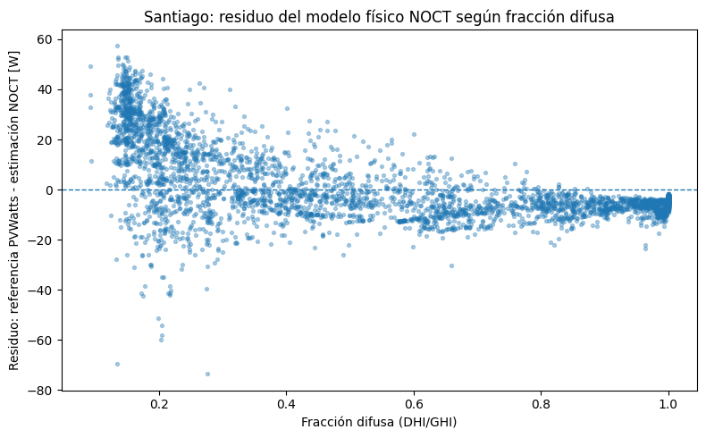

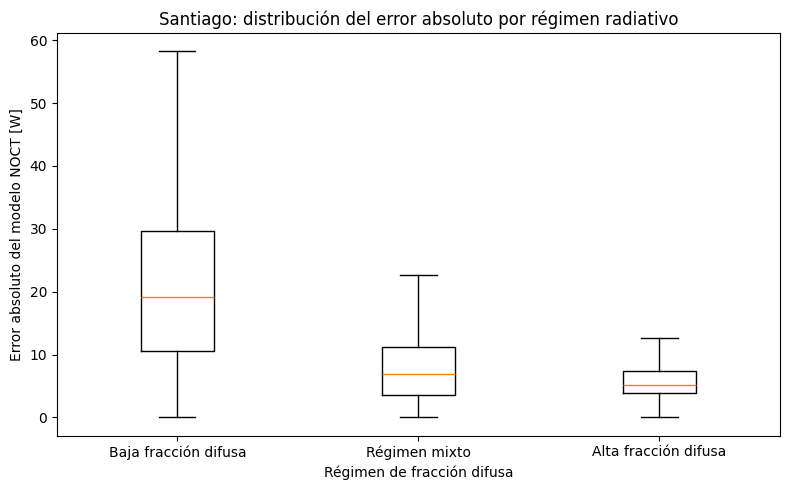

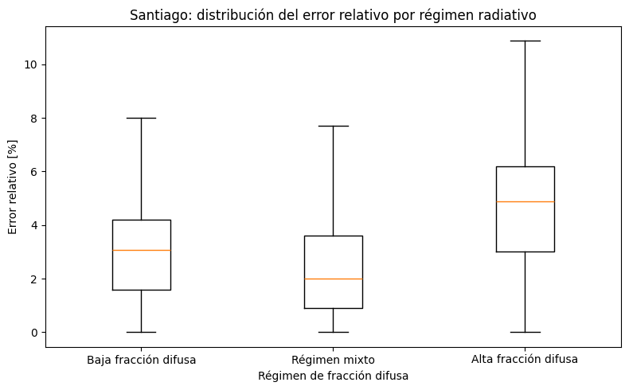

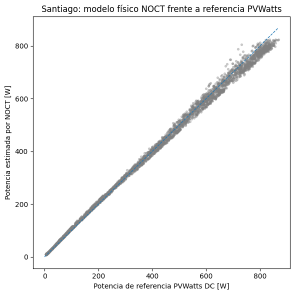

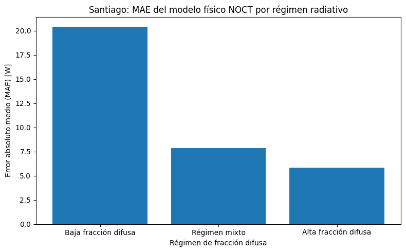

```
Archivos generados en:
outputs\03_diagnostico_fd_santiago

Tablas:
outputs\03_diagnostico_fd_santiago\metricas_globales_santiago.csv
outputs\03_diagnostico_fd_santiago\metricas_por_regimen_fd_santiago.csv
outputs\03_diagnostico_fd_santiago\correlaciones_fd_error_santiago.csv

Gráficos:
outputs\03_diagnostico_fd_santiago\bar_mae_por_regimen_santiago.png
outputs\03_diagnostico_fd_santiago\boxplot_abs_error_por_regimen_santiago.png
outputs\03_diagnostico_fd_santiago\boxplot_error_relativo_por_regimen_santiago.png
outputs\03_diagnostico_fd_santiago\scatter_epsilon_vs_fd_santiago.png
outputs\03_diagnostico_fd_santiago\scatter_pnoct_vs_pref_santiago.png
```

```python
# ============================================================
# CODIGO 3: DIAGNOSTICO DEL RESIDUO POR FRACCION DIFUSA
# ============================================================
# Este notebook responde la pregunta: el error de NOCT cambia segun fd?
# Produce metricas y graficos que justifican entrenar el modelo hibrido.
from pathlib import Path

import numpy as np
import pandas as pd
from scipy.stats import pearsonr, spearmanr
import matplotlib.pyplot as plt


# Base generada por el codigo 2, con potencia PVWatts, potencia NOCT y residuos.
INPUT_FILE = Path("data/02_noct_vs_pvwatts_santiago.csv")

# Carpeta y archivos de salida del diagnostico.
OUT_DIR = Path("outputs/03_diagnostico_fd_santiago")
OUT_DIR.mkdir(parents=True, exist_ok=True)

METRICS_GLOBAL_FILE = OUT_DIR / "metricas_globales_santiago.csv"
METRICS_REGIMEN_FILE = OUT_DIR / "metricas_por_regimen_fd_santiago.csv"
CORRELATIONS_FILE = OUT_DIR / "correlaciones_fd_error_santiago.csv"

# Orden y nombres legibles para los tres regimenes radiativos.
REGIMEN_ORDER = ["baja_fd", "mixto", "alta_fd"]
REGIMEN_LABELS = {
    "baja_fd": "Baja fracción difusa",
    "mixto": "Régimen mixto",
    "alta_fd": "Alta fracción difusa",
}



# FUNCIONES DE METRICAS
def rmse(y_true, y_pred):
    # Penaliza mas fuerte los errores grandes.
    return np.sqrt(np.mean((y_true - y_pred) ** 2))


def mae(y_true, y_pred):
    # Error promedio en watts, facil de interpretar fisicamente.
    return np.mean(np.abs(y_true - y_pred))


def bias(y_true, y_pred):
    # Bias positivo significa que el modelo sobreestima en promedio.
    # positivo = NOCT sobreestima si usamos pred - true
    return np.mean(y_pred - y_true)


def r2_score_manual(y_true, y_pred):
    # Mide que tan bien el modelo reproduce la variabilidad de la referencia.
    ss_res = np.sum((y_true - y_pred) ** 2)
    ss_tot = np.sum((y_true - np.mean(y_true)) ** 2)

    if ss_tot == 0:
        return np.nan

    return 1 - ss_res / ss_tot


def calculate_metrics(df):
    # Calcula en un solo lugar todas las metricas reportadas en el informe.
    y_true = df["p_ref_dc"]
    y_pred = df["p_noct"]

    return {
        "n": len(df),
        "n_error_relativo": df["relative_error"].notna().sum(),
        "MAE_W": mae(y_true, y_pred),
        "RMSE_W": rmse(y_true, y_pred),
        "Bias_W": bias(y_true, y_pred),
        "R2": r2_score_manual(y_true, y_pred),
        "Error_relativo_promedio": df["relative_error"].mean(),
        "P_ref_promedio_W": y_true.mean(),
        "P_NOCT_promedio_W": y_pred.mean(),
        "fd_promedio": df["fd"].mean(),
    }



# CARGA Y FILTRO
def load_data():
    # Lee el CSV del codigo 2 y conserva solo observaciones fisicamente validas.
    if not INPUT_FILE.exists():
        raise FileNotFoundError(
            f"No se encontró el archivo {INPUT_FILE}. "
            "Primero ejecuta el Código 2 para Santiago."
        )

    df = pd.read_csv(INPUT_FILE)

    required_columns = [
        "fd",
        "regimen_fd",
        "p_ref_dc",
        "p_noct",
        "epsilon",
        "abs_epsilon",
        "relative_error",
        "is_valid_model",
    ]

    missing = [col for col in required_columns if col not in df.columns]

    if missing:
        raise ValueError(f"Faltan columnas requeridas: {missing}")

    # Por si viene como texto
    # Al leer desde CSV, los booleanos pueden llegar como texto; aqui se normalizan.
    if df["is_valid_model"].dtype == "object":
        df["is_valid_model"] = df["is_valid_model"].astype(str).str.lower() == "true"

    df["regimen_fd"] = pd.Categorical(
        df["regimen_fd"],
        categories=REGIMEN_ORDER,
        ordered=True,
    )

    # is_valid_model elimina noche, irradiancia baja y fd no definida.
    df_valid = df[df["is_valid_model"]].copy()

    # Las metricas absolutas usan todas las filas fisicamente validas.
    # El error relativo se calcula solo donde relative_error no es NaN.
    df_valid = df_valid.dropna(
        subset=[
            "fd",
            "regimen_fd",
            "p_ref_dc",
            "p_noct",
            "epsilon",
            "abs_epsilon",
        ]
    )

    return df, df_valid



# TABLAS
def build_metrics_tables(df_valid):
    # Construye una tabla global y otra separada por regimen de fraccion difusa.
    metrics_global = pd.DataFrame([calculate_metrics(df_valid)])
    metrics_global.to_csv(METRICS_GLOBAL_FILE, index=False)

    rows = []

    # Se calcula el desempeno de NOCT por separado en baja, mixta y alta fd.
    for regimen in REGIMEN_ORDER:
        group = df_valid[df_valid["regimen_fd"] == regimen].copy()

        if len(group) == 0:
            continue

        row = calculate_metrics(group)
        row["regimen_fd"] = regimen
        rows.append(row)

    metrics_regimen = pd.DataFrame(rows)

    cols = ["regimen_fd"] + [c for c in metrics_regimen.columns if c != "regimen_fd"]
    metrics_regimen = metrics_regimen[cols]

    metrics_regimen.to_csv(METRICS_REGIMEN_FILE, index=False)

    return metrics_global, metrics_regimen


def build_correlations(df_valid):
    # Evalua asociacion entre fd y diferentes formas del error.
    correlations = []

    # epsilon conserva signo; abs_epsilon mide magnitud; relative_error mide proporcion.
    variables_error = ["epsilon", "abs_epsilon", "relative_error"]

    for var in variables_error:
        pearson = df_valid["fd"].corr(df_valid[var], method="pearson")
        spearman = df_valid["fd"].corr(df_valid[var], method="spearman")

        correlations.append({
            "variable_error": var,
            "corr_pearson_con_fd": pearson,
            "corr_spearman_con_fd": spearman,
        })

    corr_df = pd.DataFrame(correlations)
    corr_df.to_csv(CORRELATIONS_FILE, index=False)

    return corr_df



# GRAFICOS
def plot_epsilon_vs_fd(df_valid):
    # Permite ver si el residuo presenta estructura respecto a fd.
    plt.figure(figsize=(8, 5))
    plt.scatter(df_valid["fd"], df_valid["epsilon"], s=8, alpha=0.35)
    plt.axhline(0, linestyle="--", linewidth=1)

    plt.xlabel("Fracción difusa (DHI/GHI)")
    plt.ylabel("Residuo: referencia PVWatts - estimación NOCT [W]")
    plt.title("Santiago: residuo del modelo físico NOCT según fracción difusa")
    plt.tight_layout()

    plt.savefig(OUT_DIR / "scatter_epsilon_vs_fd_santiago.png", dpi=300)
    plt.show()


def plot_abs_error_by_regimen(df_valid):
    # Compara la magnitud del error en watts entre regimenes.
    data = [
        df_valid.loc[df_valid["regimen_fd"] == reg, "abs_epsilon"]
        for reg in REGIMEN_ORDER
    ]

    plt.figure(figsize=(8, 5))
    plt.boxplot(data, tick_labels=[REGIMEN_LABELS[reg] for reg in REGIMEN_ORDER], showfliers=False)

    plt.xlabel("Régimen de fracción difusa")
    plt.ylabel("Error absoluto del modelo NOCT [W]")
    plt.title("Santiago: distribución del error absoluto por régimen radiativo")
    plt.tight_layout()

    plt.savefig(OUT_DIR / "boxplot_abs_error_por_regimen_santiago.png", dpi=300)
    plt.show()


def plot_relative_error_by_regimen(df_valid):
    # Compara el error proporcional entre regimenes.
    data = [
        df_valid.loc[df_valid["regimen_fd"] == reg, "relative_error"].dropna() * 100
        for reg in REGIMEN_ORDER
    ]

    plt.figure(figsize=(8, 5))
    plt.boxplot(data, tick_labels=[REGIMEN_LABELS[reg] for reg in REGIMEN_ORDER], showfliers=False)

    plt.xlabel("Régimen de fracción difusa")
    plt.ylabel("Error relativo [%]")
    plt.title("Santiago: distribución del error relativo por régimen radiativo")
    plt.tight_layout()

    plt.savefig(OUT_DIR / "boxplot_error_relativo_por_regimen_santiago.png", dpi=300)
    plt.show()


def plot_pred_vs_ref(df_valid):
    # La linea diagonal representa prediccion perfecta.
    plt.figure(figsize=(6, 6))
    plt.scatter(df_valid["p_ref_dc"], df_valid["p_noct"], s=8, alpha=0.35, color="gray")

    max_val = max(df_valid["p_ref_dc"].max(), df_valid["p_noct"].max())
    plt.plot([0, max_val], [0, max_val], linestyle="--", linewidth=1)

    plt.xlabel("Potencia de referencia PVWatts DC [W]")
    plt.ylabel("Potencia estimada por NOCT [W]")
    plt.title("Santiago: modelo físico NOCT frente a referencia PVWatts")
    plt.tight_layout()

    plt.savefig(OUT_DIR / "scatter_pnoct_vs_pref_santiago.png", dpi=300)
    plt.show()


def plot_mae_by_regimen(metrics_regimen):
    # Resume visualmente la tabla de MAE por regimen.
    metrics_regimen = metrics_regimen.copy()
    metrics_regimen["regimen_fd"] = pd.Categorical(
        metrics_regimen["regimen_fd"],
        categories=REGIMEN_ORDER,
        ordered=True,
    )
    metrics_regimen = metrics_regimen.sort_values("regimen_fd")

    plt.figure(figsize=(8, 5))
    plt.bar(metrics_regimen["regimen_fd"].map(REGIMEN_LABELS), metrics_regimen["MAE_W"])

    plt.xlabel("Régimen de fracción difusa")
    plt.ylabel("Error absoluto medio (MAE) [W]")
    plt.title("Santiago: MAE del modelo físico NOCT por régimen radiativo")
    plt.tight_layout()

    plt.savefig(OUT_DIR / "bar_mae_por_regimen_santiago.png", dpi=300)
    plt.show()



# EJECUCION
def main():
    # Ejecuta el diagnostico completo y guarda tablas/graficos.
    print("Leyendo datos...")
    df, df_valid = load_data()

    print("\nFilas totales:")
    print(len(df))

    print("\nFilas válidas para diagnóstico:")
    print(len(df_valid))

    print("\nFilas con error relativo definido:")
    print(df_valid["relative_error"].notna().sum())

    print("\nConteo por régimen fd:")
    print(df_valid["regimen_fd"].value_counts().sort_index())

    print("\nCalculando métricas...")
    metrics_global, metrics_regimen = build_metrics_tables(df_valid)

    print("\nMétricas globales:")
    print(metrics_global.round(4).to_string(index=False))

    print("\nMétricas por régimen fd:")
    print(metrics_regimen.round(4).to_string(index=False))

    print("\nCalculando correlaciones...")
    corr_df = build_correlations(df_valid)

    print("\nCorrelaciones fd vs error:")
    print(corr_df.round(4).to_string(index=False))

    print("\nGenerando gráficos...")
    plot_epsilon_vs_fd(df_valid)
    plot_abs_error_by_regimen(df_valid)
    plot_relative_error_by_regimen(df_valid)
    plot_pred_vs_ref(df_valid)
    plot_mae_by_regimen(metrics_regimen)

    print("\nArchivos generados en:")
    print(OUT_DIR)

    print("\nTablas:")
    print(METRICS_GLOBAL_FILE)
    print(METRICS_REGIMEN_FILE)
    print(CORRELATIONS_FILE)

    print("\nGráficos:")
    for file in OUT_DIR.glob("*.png"):
        print(file)


if __name__ == "__main__":
    main()
```

# --- SECCIÓN: 04 MODELO HIBRIDO XGBOOST ---

# Codigo 4: modelo hibrido NOCT + XGBoost

Este notebook implementa la primera etapa de modelado hibrido mediante *residual learning*.

La idea no es reemplazar el modelo fisico NOCT, sino aprender su residuo:

$$ \epsilon = P_{ref} - P_{NOCT} $$

Luego, la potencia corregida se calcula como:

$$ P_{hybrid} = P_{NOCT} + \hat{\epsilon} $$

Se comparan tres casos:

1. **Modelo físico NOCT**, sin aprendizaje automático.
2. **Modelo híbrido sin fracción difusa**, usando variables físicas y temporales.
3. **Modelo híbrido con fracción difusa**, agregando explícitamente la fracción difusa.

La comparacion entre los modelos con y sin fracción difusa permite evaluar si la fraccion difusa aporta informacion marginal para corregir el residuo del modelo fisico.

```python
# ============================================================
# CODIGO 4: MODELO HIBRIDO RESIDUAL CON XGBOOST
# ============================================================
# Este notebook es el corazon de la tesis.
# El modelo fisico NOCT se mantiene como base y XGBoost aprende el residuo:
# epsilon = P_ref - P_NOCT.
from pathlib import Path
import json
import warnings

import numpy as np
import pandas as pd
import matplotlib.pyplot as plt

# Herramientas de aprendizaje automatico:
# metricas de evaluacion, validacion temporal y regresor XGBoost.
from sklearn.metrics import mean_absolute_error, mean_squared_error, r2_score
from sklearn.model_selection import TimeSeriesSplit
from xgboost import XGBRegressor

# Configuracion visual y limpieza de advertencias para que el notebook sea mas legible.
warnings.filterwarnings("ignore")
plt.style.use("seaborn-v0_8-whitegrid")
```

```python
# ============================================================
# CONFIGURACION
# ============================================================

# Entrada y salida.
# La entrada es la base final del codigo 2; las salidas son metricas, graficos y predicciones.
INPUT_FILE = Path("data/02_noct_vs_pvwatts_santiago.csv")
OUT_DIR = Path("outputs/04_modelo_hibrido_xgboost_santiago")
OUT_DIR.mkdir(parents=True, exist_ok=True)

# Parametros generales de experimento.
# RANDOM_STATE mejora reproducibilidad y TEST_FRACTION define el bloque temporal de prueba.
RANDOM_STATE = 42
TEST_FRACTION = 0.25
P_REF_MIN_RELATIVE_ERROR = 50.0

# Variable objetivo: XGBoost no aprende potencia directamente, aprende el residuo de NOCT.
TARGET = "epsilon"

# Variables predictoras.
# El modelo sin fd evita DHI, DNI y GHI para que fd no entre de forma implicita.
# Variables disponibles antes de conocer la potencia de referencia.
# Se evita incluir DHI, DNI o GHI en el modelo sin fd, porque desde ellas se podria reconstruir fd.
FEATURES_BASE = [
    "poa",
    "temperature",
    "wind_speed",
    "hour_sin",
    "hour_cos",
    "month_sin",
    "month_cos",
]

FEATURES_WITH_FD = FEATURES_BASE + ["fd"]

# Nombres legibles para tablas y graficos.
MODEL_NOCT = "Modelo físico NOCT"
MODEL_XGB_SIN_FD = "Modelo híbrido sin fracción difusa"
MODEL_XGB_CON_FD = "Modelo híbrido con fracción difusa"
MODEL_ORDER = [MODEL_NOCT, MODEL_XGB_SIN_FD, MODEL_XGB_CON_FD]
MODEL_GRAPH_LABELS = {
    MODEL_NOCT: "Físico NOCT",
    MODEL_XGB_SIN_FD: "Híbrido sin\nfracción difusa",
    MODEL_XGB_CON_FD: "Híbrido con\nfracción difusa",
}
MODEL_LEGEND_LABELS = {
    MODEL_NOCT: "Modelo físico NOCT",
    MODEL_XGB_SIN_FD: "Híbrido sin fracción difusa",
    MODEL_XGB_CON_FD: "Híbrido con fracción difusa",
}

# Orden fijo para comparar baja, mixta y alta fraccion difusa.
REGIMEN_ORDER = ["baja_fd", "mixto", "alta_fd"]
REGIMEN_LABELS = {
    "baja_fd": "Baja fracción difusa",
    "mixto": "Régimen mixto",
    "alta_fd": "Alta fracción difusa",
}
# Diccionario para mostrar nombres de variables claros en los graficos.
FEATURE_LABELS = {
    "fd": "Fracción difusa",
    "wind_speed": "Velocidad de viento",
    "poa": "Irradiancia en el plano del panel",
    "temperature": "Temperatura ambiente",
    "hour_sin": "Hora del día (seno)",
    "hour_cos": "Hora del día (coseno)",
    "month_sin": "Mes del año (seno)",
    "month_cos": "Mes del año (coseno)",
}

# Hiperparametros de XGBoost.
# Se usa un modelo moderado y regularizado para evitar sobreajuste excesivo.
XGB_PARAMS = {
    "objective": "reg:squarederror",
    "n_estimators": 350,
    "max_depth": 3,
    "learning_rate": 0.035,
    "subsample": 0.85,
    "colsample_bytree": 0.85,
    "min_child_weight": 3,
    "reg_lambda": 2.0,
    "random_state": RANDOM_STATE,
    "n_jobs": -1,
}

print("Archivo de entrada:", INPUT_FILE)
print("Carpeta de salida:", OUT_DIR)
```

```
Archivo de entrada: data\02_noct_vs_pvwatts_santiago.csv
Carpeta de salida: outputs\04_modelo_hibrido_xgboost_santiago
```

## 1. Carga y preparacion de datos

Se usan solamente las observaciones marcadas como validas por el Codigo 2. Ademas, se generan variables ciclicas para hora y mes, evitando tratar estas variables como numeros lineales.

```python
def parse_bool_column(series):
    # Normaliza columnas booleanas que pueden venir como texto desde CSV.
    if series.dtype == bool:
        return series
    if series.dtype == object:
        return series.astype(str).str.lower().isin(["true", "1", "yes", "si"])
    return series.astype(bool)


def add_cyclical_features(df):
    # Codifica hora y mes como senos/cosenos para representar ciclos.
    # Asi 23:00 y 00:00 quedan cerca matematicamente.
    df = df.copy()
    df["hour_sin"] = np.sin(2 * np.pi * df["hour"] / 24)
    df["hour_cos"] = np.cos(2 * np.pi * df["hour"] / 24)
    df["month_sin"] = np.sin(2 * np.pi * (df["month"] - 1) / 12)
    df["month_cos"] = np.cos(2 * np.pi * (df["month"] - 1) / 12)
    return df


# Columnas minimas necesarias para entrenar y evaluar el modelo hibrido.
required_columns = {
    "datetime_local",
    "month",
    "hour",
    "regimen_fd",
    "fd",
    "poa",
    "temperature",
    "wind_speed",
    "p_ref_dc",
    "p_noct",
    "epsilon",
    "relative_error",
    "is_valid_model",
}

# Validacion de existencia del archivo de entrada.
if not INPUT_FILE.exists():
    raise FileNotFoundError(f"No existe {INPUT_FILE}. Ejecuta primero los Codigos 1 y 2.")

# Lectura de la base y validacion de columnas.
df_raw = pd.read_csv(INPUT_FILE)
missing = sorted(required_columns - set(df_raw.columns))
if missing:
    raise ValueError(f"Faltan columnas requeridas: {missing}")

# Preparacion temporal y variables ciclicas.
df = df_raw.copy()
df["is_valid_model"] = parse_bool_column(df["is_valid_model"])
df["datetime_local"] = pd.to_datetime(df["datetime_local"])
df = df.sort_values("datetime_local").reset_index(drop=True)
df = add_cyclical_features(df)

# Seleccion de columnas utiles para modelado.
# Se conservan variables predictoras, objetivo, referencia y metadatos de evaluacion.
model_columns = sorted(set(FEATURES_WITH_FD + [TARGET, "p_ref_dc", "p_noct", "regimen_fd", "datetime_local", "relative_error"]))
model_df = df.loc[df["is_valid_model"], model_columns].copy()
# Limpieza: se eliminan infinitos/NaN en variables necesarias para entrenar.
model_df = model_df.replace([np.inf, -np.inf], np.nan)
model_df = model_df.dropna(subset=FEATURES_WITH_FD + [TARGET, "p_ref_dc", "p_noct"])
model_df = model_df.sort_values("datetime_local").reset_index(drop=True)

print("Filas totales:", len(df_raw))
print("Filas validas para modelado:", len(model_df))
print("Periodo:", model_df["datetime_local"].min(), "a", model_df["datetime_local"].max())
print("Distribucion por regimen fd:")
print(model_df["regimen_fd"].value_counts().sort_index())
```

```
Filas totales: 8760
Filas validas para modelado: 4215
Periodo: 2021-01-01 06:00:00 a 2021-12-31 19:00:00
Distribucion por regimen fd:
regimen_fd
alta_fd    1740
baja_fd    1349
mixto      1126
Name: count, dtype: int64
```

## 2. Separacion temporal

No se usa division aleatoria, porque los datos horarios tienen autocorrelacion temporal. Se deja el ultimo 25% de la serie como conjunto de prueba. Esta eleccion es conservadora para evitar que horas vecinas muy similares aparezcan simultaneamente en entrenamiento y prueba.

```python
# Separacion temporal train/test.
# No se mezcla aleatoriamente porque los datos son una serie horaria.
split_index = int(len(model_df) * (1 - TEST_FRACTION))
train_df = model_df.iloc[:split_index].copy()
test_df = model_df.iloc[split_index:].copy()

# Marca auxiliar para saber que filas quedaron en entrenamiento o prueba.
model_df["split"] = "train"
model_df.loc[model_df.index >= split_index, "split"] = "test"

print("Train:", len(train_df), train_df["datetime_local"].min(), "a", train_df["datetime_local"].max())
print("Test :", len(test_df), test_df["datetime_local"].min(), "a", test_df["datetime_local"].max())
print("\nTrain por regimen fd:")
print(train_df["regimen_fd"].value_counts().sort_index())
print("\nTest por regimen fd:")
print(test_df["regimen_fd"].value_counts().sort_index())
```

```
Train: 3161 2021-01-01 06:00:00 a 2021-10-13 09:00:00
Test : 1054 2021-10-13 10:00:00 a 2021-12-31 19:00:00

Train por regimen fd:
regimen_fd
alta_fd    1420
baja_fd     907
mixto       834
Name: count, dtype: int64

Test por regimen fd:
regimen_fd
alta_fd    320
baja_fd    442
mixto      292
Name: count, dtype: int64
```

## 3. Funciones de entrenamiento y evaluacion

```python
def fit_xgb_residual(train, features):
    # Entrena XGBoost para predecir epsilon, no la potencia total.
    model = XGBRegressor(**XGB_PARAMS)
    model.fit(train[features], train[TARGET])
    return model


def add_predictions(df_eval, model, features, suffix):
    # Convierte la prediccion de residuo en potencia hibrida:
    # P_hybrid = P_NOCT + epsilon_hat.
    df_out = df_eval.copy()
    eps_hat_col = f"epsilon_hat_{suffix}"
    p_col = f"p_hybrid_{suffix}"
    # epsilon_hat es la correccion aprendida por XGBoost.
    df_out[eps_hat_col] = model.predict(df_out[features])
    # Se suma la correccion al modelo fisico base.
    raw_p = df_out["p_noct"] + df_out[eps_hat_col]
    clip_count = (raw_p < 0).sum()
    print(f"\n[{suffix}] Evaluando clipping...")
    print(f"Veces que P_hybrid < 0 antes del clipping: {clip_count} de {len(raw_p)} observaciones ({(clip_count/len(raw_p))*100:.2f}%)")
    df_out[p_col] = raw_p.clip(lower=0)
    return df_out[[eps_hat_col, p_col]]


def evaluate_power(y_true, y_pred, name, dataset_name):
    # Calcula metricas comparando una potencia estimada contra la referencia PVWatts.
    error = y_pred - y_true
    abs_error = np.abs(error)
    # El error relativo se calcula solo para potencias de referencia suficientemente altas.
    rel_mask = y_true > P_REF_MIN_RELATIVE_ERROR
    out = {
        "dataset": dataset_name,
        "modelo": name,
        "n": int(len(y_true)),
        "n_error_relativo": int(rel_mask.sum()),
        "MAE_W": float(mean_absolute_error(y_true, y_pred)),
        "RMSE_W": float(np.sqrt(mean_squared_error(y_true, y_pred))),
        "Bias_W_modelo_menos_ref": float(np.mean(error)),
        "R2": float(r2_score(y_true, y_pred)),
        "Error_relativo_promedio": float((abs_error[rel_mask] / y_true[rel_mask]).mean()) if rel_mask.sum() else np.nan,
    }
    return out


def evaluate_models(df_eval, dataset_name):
    # Evalua en conjunto NOCT, hibrido sin fd e hibrido con fd.
    rows = []
    rows.append(evaluate_power(df_eval["p_ref_dc"], df_eval["p_noct"], MODEL_NOCT, dataset_name))
    rows.append(evaluate_power(df_eval["p_ref_dc"], df_eval["p_hybrid_sin_fd"], MODEL_XGB_SIN_FD, dataset_name))
    rows.append(evaluate_power(df_eval["p_ref_dc"], df_eval["p_hybrid_con_fd"], MODEL_XGB_CON_FD, dataset_name))
    metrics = pd.DataFrame(rows)
    noct_mae = metrics.loc[metrics["modelo"] == MODEL_NOCT, "MAE_W"].iloc[0]
    # Mejora porcentual del MAE respecto al modelo fisico base.
    metrics["Mejora_MAE_vs_NOCT_pct"] = (noct_mae - metrics["MAE_W"]) / noct_mae * 100
    return metrics
```

## 4. Entrenamiento de modelos residuales

```python
# Entrenamiento de los dos modelos residuales.
# Ambos aprenden epsilon; la unica diferencia es si reciben fd como entrada.
model_sin_fd = fit_xgb_residual(train_df, FEATURES_BASE)
model_con_fd = fit_xgb_residual(train_df, FEATURES_WITH_FD)

# Predicciones sobre el conjunto de prueba, que simula datos futuros no vistos.
test_pred = test_df.copy()
test_pred = pd.concat(
    [
        test_pred,
        add_predictions(test_df, model_sin_fd, FEATURES_BASE, "sin_fd"),
        add_predictions(test_df, model_con_fd, FEATURES_WITH_FD, "con_fd"),
    ],
    axis=1,
)

# Predicciones sobre entrenamiento para comparar ajuste interno vs prueba.
train_pred = train_df.copy()
train_pred = pd.concat(
    [
        train_pred,
        add_predictions(train_df, model_sin_fd, FEATURES_BASE, "sin_fd"),
        add_predictions(train_df, model_con_fd, FEATURES_WITH_FD, "con_fd"),
    ],
    axis=1,
)

# Metricas finales de train y test.
metrics_train = evaluate_models(train_pred, "train")
metrics_test = evaluate_models(test_pred, "test")
metrics_all = pd.concat([metrics_train, metrics_test], ignore_index=True)

metrics_all
```

```
[sin_fd] Evaluando clipping...
Veces que P_hybrid < 0 antes del clipping: 0 de 1054 observaciones (0.00%)

[con_fd] Evaluando clipping...
Veces que P_hybrid < 0 antes del clipping: 0 de 1054 observaciones (0.00%)

[sin_fd] Evaluando clipping...
Veces que P_hybrid < 0 antes del clipping: 0 de 3161 observaciones (0.00%)

[con_fd] Evaluando clipping...
Veces que P_hybrid < 0 antes del clipping: 0 de 3161 observaciones (0.00%)
```

|  | dataset | modelo | n | n_error_relativo | MAE_W | RMSE_W | Bias_W_modelo_menos_ref | R2 | Error_relativo_promedio | Mejora_MAE_vs_NOCT_pct |
| --- | --- | --- | --- | --- | --- | --- | --- | --- | --- | --- |
| 0 | train | Modelo físico NOCT | 3161 | 2741 | 10.301977 | 14.300970 | -0.789768 | 0.996903 | 0.036405 | 0.000000 |
| 1 | train | Modelo híbrido sin fracción difusa | 3161 | 2741 | 1.460972 | 2.015711 | 0.000733 | 0.999938 | 0.006013 | 85.818524 |
| 2 | train | Modelo híbrido con fracción difusa | 3161 | 2741 | 1.108010 | 1.486767 | 0.000444 | 0.999967 | 0.004512 | 89.244682 |
| 3 | test | Modelo físico NOCT | 1054 | 947 | 13.296102 | 17.103093 | -4.049339 | 0.996300 | 0.039592 | 0.000000 |
| 4 | test | Modelo híbrido sin fracción difusa | 1054 | 947 | 2.702791 | 3.727646 | 0.924285 | 0.999824 | 0.009406 | 79.672303 |
| 5 | test | Modelo híbrido con fracción difusa | 1054 | 947 | 2.224713 | 3.013470 | 1.127999 | 0.999885 | 0.008264 | 83.267929 |

## 5. Metricas por regimen de fraccion difusa

Estas metricas permiten verificar si la correccion mejora de manera uniforme o si el beneficio se concentra en algun regimen radiativo.

```python
# Evaluacion por regimen fd.
# Permite ver si la mejora del modelo hibrido es uniforme o depende de baja/mixta/alta fd.
regimen_rows = []
for regimen, group in test_pred.groupby("regimen_fd"):
    for row in evaluate_models(group, f"test_{regimen}").to_dict("records"):
        row["regimen_fd"] = regimen
        regimen_rows.append(row)

metrics_regimen = pd.DataFrame(regimen_rows)
metrics_regimen = metrics_regimen[
    ["regimen_fd", "dataset", "modelo", "n", "n_error_relativo", "MAE_W", "RMSE_W", "Bias_W_modelo_menos_ref", "R2", "Error_relativo_promedio", "Mejora_MAE_vs_NOCT_pct"]
]
metrics_regimen
```

|  | regimen_fd | dataset | modelo | n | n_error_relativo | MAE_W | RMSE_W | Bias_W_modelo_menos_ref | R2 | Error_relativo_promedio | Mejora_MAE_vs_NOCT_pct |
| --- | --- | --- | --- | --- | --- | --- | --- | --- | --- | --- | --- |
| 0 | alta_fd | test_alta_fd | Modelo físico NOCT | 320 | 215 | 6.155522 | 6.946511 | 5.997392 | 0.997734 | 0.054868 | 0.000000 |
| 1 | alta_fd | test_alta_fd | Modelo híbrido sin fracción difusa | 320 | 215 | 2.635728 | 3.984164 | 1.251701 | 0.999255 | 0.017243 | 57.181088 |
| 2 | alta_fd | test_alta_fd | Modelo híbrido con fracción difusa | 320 | 215 | 1.832645 | 2.583016 | 0.696829 | 0.999687 | 0.012940 | 70.227631 |
| 3 | baja_fd | test_baja_fd | Modelo físico NOCT | 442 | 442 | 21.127128 | 24.207943 | -16.891806 | 0.965323 | 0.030270 | 0.000000 |
| 4 | baja_fd | test_baja_fd | Modelo híbrido sin fracción difusa | 442 | 442 | 2.337774 | 3.251522 | -0.336584 | 0.999374 | 0.003522 | 88.934729 |
| 5 | baja_fd | test_baja_fd | Modelo híbrido con fracción difusa | 442 | 442 | 2.027759 | 2.710158 | 0.917979 | 0.999565 | 0.003009 | 90.402105 |
| 6 | mixto | test_mixto | Modelo físico NOCT | 292 | 290 | 9.267581 | 10.766438 | 4.380169 | 0.996952 | 0.042473 | 0.000000 |
| 7 | mixto | test_mixto | Modelo híbrido sin fracción difusa | 292 | 290 | 3.328812 | 4.093578 | 2.474046 | 0.999559 | 0.012565 | 64.081116 |
| 8 | mixto | test_mixto | Modelo híbrido con fracción difusa | 292 | 290 | 2.952506 | 3.787993 | 1.918422 | 0.999623 | 0.012807 | 68.141572 |

## 6. Validacion temporal adicional con `TimeSeriesSplit`

Ademas del holdout temporal final, se calcula una validacion temporal por bloques crecientes. Esta salida es diagnostica: ayuda a ver si la mejora es estable en mas de una particion temporal.

```python
def run_time_series_cv(df_cv, features, model_name, n_splits=5):
    # Validacion temporal adicional.
    # Cada fold entrena con datos anteriores y prueba con un bloque posterior.
    # TimeSeriesSplit respeta el orden temporal, a diferencia de una validacion aleatoria.
    tscv = TimeSeriesSplit(n_splits=n_splits)
    rows = []
    total_clip = 0
    total_obs = 0
    for fold, (train_idx, test_idx) in enumerate(tscv.split(df_cv), start=1):
        fold_train = df_cv.iloc[train_idx].copy()
        fold_test = df_cv.iloc[test_idx].copy()
        # Se entrena un modelo nuevo en cada fold para evaluar estabilidad temporal.
        model = fit_xgb_residual(fold_train, features)
        pred = fold_test.copy()
        eps_hat = model.predict(pred[features])
        raw_p = pred["p_noct"] + eps_hat
        total_clip += (raw_p < 0).sum()
        total_obs += len(raw_p)
        pred_power = raw_p.clip(lower=0)
        row = evaluate_power(pred["p_ref_dc"], pred_power, model_name, f"cv_fold_{fold}")
        row["fold"] = fold
        row["train_inicio"] = fold_train["datetime_local"].min()
        row["train_fin"] = fold_train["datetime_local"].max()
        row["test_inicio"] = fold_test["datetime_local"].min()
        row["test_fin"] = fold_test["datetime_local"].max()
        rows.append(row)
    print(f"\n[CV {model_name}] Evaluando clipping (total sobre {n_splits} folds)...")
    print(f"Veces que P_hybrid < 0 antes del clipping: {total_clip} de {total_obs} observaciones ({(total_clip/total_obs)*100:.2f}%)")
    return pd.DataFrame(rows)

# Se compara la estabilidad temporal del modelo sin fd y con fd.
cv_sin_fd = run_time_series_cv(model_df, FEATURES_BASE, MODEL_XGB_SIN_FD)
cv_con_fd = run_time_series_cv(model_df, FEATURES_WITH_FD, MODEL_XGB_CON_FD)
cv_metrics = pd.concat([cv_sin_fd, cv_con_fd], ignore_index=True)
cv_metrics
```

```
[CV Modelo híbrido sin fracción difusa] Evaluando clipping (total sobre 5 folds)...
Veces que P_hybrid < 0 antes del clipping: 0 de 3510 observaciones (0.00%)
```

```
[CV Modelo híbrido con fracción difusa] Evaluando clipping (total sobre 5 folds)...
Veces que P_hybrid < 0 antes del clipping: 0 de 3510 observaciones (0.00%)
```

|  | dataset | modelo | n | n_error_relativo | MAE_W | RMSE_W | Bias_W_modelo_menos_ref | R2 | Error_relativo_promedio | fold | train_inicio | train_fin | test_inicio | test_fin |
| --- | --- | --- | --- | --- | --- | --- | --- | --- | --- | --- | --- | --- | --- | --- |
| 0 | cv_fold_1 | Modelo híbrido sin fracción difusa | 702 | 624 | 4.603619 | 5.988951 | -4.125014 | 0.999499 | 0.016318 | 1 | 2021-01-01 06:00:00 | 2021-02-21 18:00:00 | 2021-02-22 07:00:00 | 2021-04-24 09:00:00 |
| 1 | cv_fold_2 | Modelo híbrido sin fracción difusa | 702 | 585 | 4.872571 | 6.221028 | -4.282700 | 0.999035 | 0.025863 | 2 | 2021-01-01 06:00:00 | 2021-04-24 09:00:00 | 2021-04-24 10:00:00 | 2021-07-05 14:00:00 |
| 2 | cv_fold_3 | Modelo híbrido sin fracción difusa | 702 | 595 | 1.918335 | 2.646231 | 0.814681 | 0.999840 | 0.007627 | 3 | 2021-01-01 06:00:00 | 2021-07-05 14:00:00 | 2021-07-05 15:00:00 | 2021-09-12 15:00:00 |
| 3 | cv_fold_4 | Modelo híbrido sin fracción difusa | 702 | 614 | 3.113432 | 4.090541 | 1.437711 | 0.999761 | 0.010382 | 4 | 2021-01-01 06:00:00 | 2021-09-12 15:00:00 | 2021-09-12 16:00:00 | 2021-11-09 14:00:00 |
| 4 | cv_fold_5 | Modelo híbrido sin fracción difusa | 702 | 649 | 2.358570 | 3.272550 | 0.828100 | 0.999864 | 0.008868 | 5 | 2021-01-01 06:00:00 | 2021-11-09 14:00:00 | 2021-11-09 15:00:00 | 2021-12-31 19:00:00 |
| 5 | cv_fold_1 | Modelo híbrido con fracción difusa | 702 | 624 | 3.455487 | 4.680571 | -2.880356 | 0.999694 | 0.012798 | 1 | 2021-01-01 06:00:00 | 2021-02-21 18:00:00 | 2021-02-22 07:00:00 | 2021-04-24 09:00:00 |
| 6 | cv_fold_2 | Modelo híbrido con fracción difusa | 702 | 585 | 2.793433 | 3.566460 | -2.401389 | 0.999683 | 0.014348 | 2 | 2021-01-01 06:00:00 | 2021-04-24 09:00:00 | 2021-04-24 10:00:00 | 2021-07-05 14:00:00 |
| 7 | cv_fold_3 | Modelo híbrido con fracción difusa | 702 | 595 | 1.806144 | 2.521308 | 0.859539 | 0.999855 | 0.007577 | 3 | 2021-01-01 06:00:00 | 2021-07-05 14:00:00 | 2021-07-05 15:00:00 | 2021-09-12 15:00:00 |
| 8 | cv_fold_4 | Modelo híbrido con fracción difusa | 702 | 614 | 2.456633 | 3.281274 | 1.316650 | 0.999846 | 0.009282 | 4 | 2021-01-01 06:00:00 | 2021-09-12 15:00:00 | 2021-09-12 16:00:00 | 2021-11-09 14:00:00 |
| 9 | cv_fold_5 | Modelo híbrido con fracción difusa | 702 | 649 | 2.115604 | 2.734299 | 1.224833 | 0.999905 | 0.008025 | 5 | 2021-01-01 06:00:00 | 2021-11-09 14:00:00 | 2021-11-09 15:00:00 | 2021-12-31 19:00:00 |

## 7. Importancia de variables

La importancia de variables de XGBoost se interpreta como una senal diagnostica del modelo, no como una prueba causal.

```python
# Importancia de variables.
# Sirve como diagnostico predictivo: indica que variables uso XGBoost para reducir el residuo.
importance_con_fd = pd.DataFrame({
    "feature": FEATURES_WITH_FD,
    "importance": model_con_fd.feature_importances_,
}).sort_values("importance", ascending=False).reset_index(drop=True)

# Se guarda tambien la importancia del modelo sin fd para comparacion interna.
importance_sin_fd = pd.DataFrame({
    "feature": FEATURES_BASE,
    "importance": model_sin_fd.feature_importances_,
}).sort_values("importance", ascending=False).reset_index(drop=True)

importance_con_fd
```

|  | feature | importance |
| --- | --- | --- |
| 0 | fd | 0.298570 |
| 1 | wind_speed | 0.238947 |
| 2 | poa | 0.157436 |
| 3 | temperature | 0.142494 |
| 4 | hour_sin | 0.061704 |
| 5 | hour_cos | 0.056000 |
| 6 | month_cos | 0.033405 |
| 7 | month_sin | 0.011445 |

## 8. Graficos

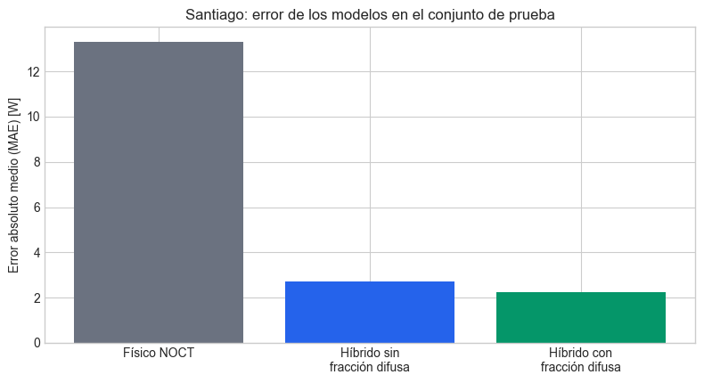

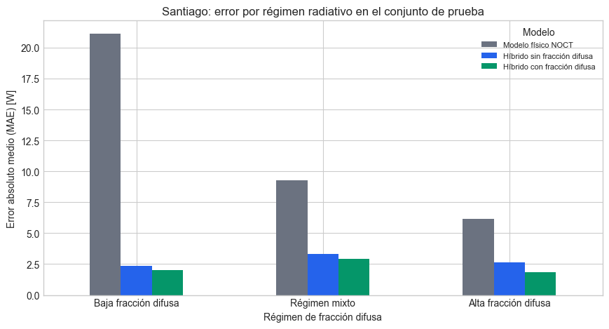

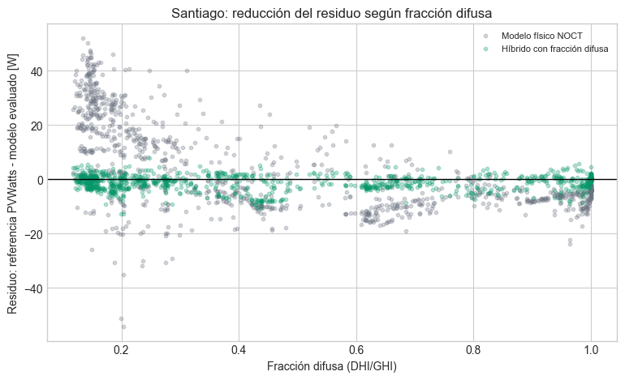

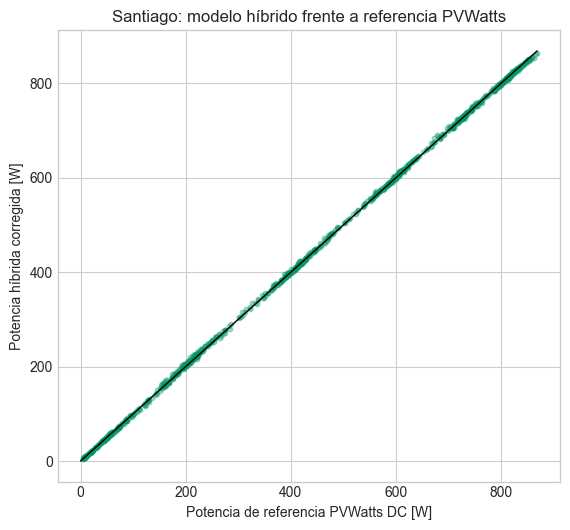

[figure not shown]

```python
def savefig(path):
    # Guarda cada figura en alta resolucion y la muestra en el notebook.
    plt.tight_layout()
    plt.savefig(path, dpi=300, bbox_inches="tight")
    plt.show()

# ============================================================
# Graficos principales usados en el informe
# ============================================================
# Error global en test.
plt.figure(figsize=(8.0, 4.4))
plot_df = metrics_test.copy()
plot_df["modelo"] = pd.Categorical(plot_df["modelo"], categories=MODEL_ORDER, ordered=True)
plot_df = plot_df.sort_values("modelo")
plt.bar(plot_df["modelo"].map(MODEL_GRAPH_LABELS), plot_df["MAE_W"], color=["#6b7280", "#2563eb", "#059669"])
plt.ylabel("Error absoluto medio (MAE) [W]")
plt.title("Santiago: error de los modelos en el conjunto de prueba")
plt.xticks(rotation=0, ha="center")
savefig(OUT_DIR / "bar_mae_modelos_test_santiago.png")

# Error por regimen en test.
plt.figure(figsize=(8.8, 4.8))
# Tabla pivote para graficar modelos lado a lado por regimen.
pivot = metrics_regimen.pivot(index="regimen_fd", columns="modelo", values="MAE_W")
pivot = pivot.reindex(REGIMEN_ORDER)
pivot = pivot[MODEL_ORDER]
pivot = pivot.rename(index=REGIMEN_LABELS, columns=MODEL_LEGEND_LABELS)
pivot.plot(kind="bar", ax=plt.gca(), color=["#6b7280", "#2563eb", "#059669"])
plt.ylabel("Error absoluto medio (MAE) [W]")
plt.xlabel("Régimen de fracción difusa")
plt.title("Santiago: error por régimen radiativo en el conjunto de prueba")
plt.xticks(rotation=0)
plt.legend(title="Modelo", fontsize=8)
savefig(OUT_DIR / "bar_mae_por_regimen_modelos_santiago.png")

# Residuo vs fraccion difusa antes y despues de la correccion.
plt.figure(figsize=(7.8, 4.8))
# Se comparan residuos antes y despues de la correccion hibrida.
res_noct = test_pred["p_ref_dc"] - test_pred["p_noct"]
res_hybrid = test_pred["p_ref_dc"] - test_pred["p_hybrid_con_fd"]
plt.scatter(test_pred["fd"], res_noct, s=10, alpha=0.28, label="Modelo físico NOCT", color="#6b7280")
plt.scatter(test_pred["fd"], res_hybrid, s=10, alpha=0.28, label="Híbrido con fracción difusa", color="#059669")
plt.axhline(0, color="black", linewidth=1)
plt.xlabel("Fracción difusa (DHI/GHI)")
plt.ylabel("Residuo: referencia PVWatts - modelo evaluado [W]")
plt.title("Santiago: reducción del residuo según fracción difusa")
plt.legend(fontsize=8)
savefig(OUT_DIR / "scatter_residuo_vs_fd_noct_hibrido_santiago.png")

# Potencia hibrida corregida vs referencia.
plt.figure(figsize=(5.8, 5.4))
plt.scatter(test_pred["p_ref_dc"], test_pred["p_hybrid_con_fd"], s=10, alpha=0.35, color="#059669")
# Linea 1:1: si el modelo fuera perfecto, todos los puntos caerian sobre esta diagonal.
max_val = max(test_pred["p_ref_dc"].max(), test_pred["p_hybrid_con_fd"].max())
plt.plot([0, max_val], [0, max_val], color="black", linewidth=1)
plt.xlabel("Potencia de referencia PVWatts DC [W]")
plt.ylabel("Potencia híbrida corregida [W]")
plt.title("Santiago: modelo híbrido frente a referencia PVWatts")
savefig(OUT_DIR / "scatter_phybrid_con_fd_vs_pref_santiago.png")

# Importancia de variables del modelo con fraccion difusa.
plt.figure(figsize=(8.4, 4.8))
# El grafico de importancia muestra que variables aportan mas al XGBoost con fd.
imp = importance_con_fd.sort_values("importance", ascending=True).copy()
imp["feature_label"] = imp["feature"].map(FEATURE_LABELS).fillna(imp["feature"])
plt.barh(imp["feature_label"], imp["importance"], color="#059669")
plt.xlabel("Importancia relativa en XGBoost")
plt.title("Santiago: variables más influyentes en la corrección residual")
savefig(OUT_DIR / "bar_importancia_xgboost_con_fd_santiago.png")
```

## 9. Guardado de resultados

```python
# Guardado de tablas, predicciones y metadata.
# Estos archivos son los que luego se usan para reportar resultados en el informe.
metrics_all.to_csv(OUT_DIR / "metricas_modelos_train_test_santiago.csv", index=False)
metrics_test.to_csv(OUT_DIR / "metricas_modelos_test_santiago.csv", index=False)
metrics_regimen.to_csv(OUT_DIR / "metricas_modelos_test_por_regimen_santiago.csv", index=False)
cv_metrics.to_csv(OUT_DIR / "validacion_temporal_timeseries_split_santiago.csv", index=False)
importance_con_fd.to_csv(OUT_DIR / "importancia_xgboost_con_fd_santiago.csv", index=False)
importance_sin_fd.to_csv(OUT_DIR / "importancia_xgboost_sin_fd_santiago.csv", index=False)

test_pred.to_csv(OUT_DIR / "predicciones_test_modelo_hibrido_santiago.csv", index=False)
train_pred.to_csv(OUT_DIR / "predicciones_train_modelo_hibrido_santiago.csv", index=False)

# Metadata metodologica del modelo hibrido para dejar trazabilidad del experimento.
metadata = {
    "input_file": str(INPUT_FILE),
    "output_dir": str(OUT_DIR),
    "target": TARGET,
    "features_base": FEATURES_BASE,
    "features_with_fd": FEATURES_WITH_FD,
    "test_fraction": TEST_FRACTION,
    "split_type": "chronological_holdout_last_fraction",
    "p_ref_min_relative_error": P_REF_MIN_RELATIVE_ERROR,
    "xgboost_params": XGB_PARAMS,
    "notes": [
        "El modelo aprende el residuo epsilon = P_ref - P_NOCT.",
        "El modelo sin fd evita DHI, DNI y GHI para no reconstruir implicitamente la fraccion difusa.",
        "La evaluacion principal usa separacion temporal, no aleatoria.",
        "Las importancias de variables son diagnosticas y no constituyen evidencia causal.",
    ],
}

# Escritura de metadata en JSON legible.
with open(OUT_DIR / "metadata_modelo_hibrido_santiago.json", "w", encoding="utf-8") as f:
    json.dump(metadata, f, indent=4, ensure_ascii=False)

print("Resultados guardados en:", OUT_DIR)
print("\nMetricas test:")
print(metrics_test.to_string(index=False))
```

```
Resultados guardados en: outputs\04_modelo_hibrido_xgboost_santiago

Metricas test:
dataset                             modelo    n  n_error_relativo     MAE_W    RMSE_W  Bias_W_modelo_menos_ref       R2  Error_relativo_promedio  Mejora_MAE_vs_NOCT_pct
   test                 Modelo físico NOCT 1054               947 13.296102 17.103093                -4.049339 0.996300                 0.039592                0.000000
   test Modelo híbrido sin fracción difusa 1054               947  2.702791  3.727646                 0.924285 0.999824                 0.009406               79.672303
   test Modelo híbrido con fracción difusa 1054               947  2.224713  3.013470                 1.127999 0.999885                 0.008264               83.267929
```

## 10. Lectura preliminar

La conclusion metodologica debe basarse en la comparacion del conjunto de prueba:

- Si el híbrido con fracción difusa mejora al NOCT base, entonces existe estructura residual aprovechable.
- Si el híbrido con fracción difusa mejora al híbrido sin fracción difusa, entonces la fracción difusa aporta información marginal bajo esta configuracion.
- Si la mejora aparece solo en entrenamiento y no en prueba, no debe interpretarse como mejora real.

Esta etapa sigue usando una referencia simulada de PVWatts, por lo que los resultados no sustituyen una validacion experimental con mediciones reales.